# MLAnalysis

Val F. Lanza

2022-12-02

```r
library(tidyverse)

library(vegan)
library(ggrepel)
library(ggsci)
library(tidymodels)
library(easystats)
library(emmeans)
library(gamlss)
```

# Cargamos los datos

```r
setwd("/storage2/Murciano/")

table <- read_csv("/storage2/Murciano/FASTQs/nextflow/edger/mature_counts.csv") %>% rename(Sample = 1)
```

```
## ──────────────────────────────────────────────────────── Delimiter: "," chr
## (1): ...1 dbl (264): hsa-let-7a-5p, hsa-let-7b-5p, hsa-let-7c-5p,
## hsa-let-7d-5p, hsa-l...
```

```r
meta <- read_tsv("/storage2/Murciano/Metadata.tsv")
cond <-  meta %>%
  column_to_rownames("Sample")
```

# Quality Control

Puedes encontrar un extenso quality control en la siguiente dirección https://irycisbioinfo.github.io/jcmurciano/multiqc_report.html

Primero vamos a observar como es la distribución de los Reads en las muestras.

```r
table %>%
  pivot_longer(names_to = "miRNA", values_to = "counts", cols = -Sample) %>%
  group_by(Sample) %>%
  summarise(Total = sum(counts)) %>%
  arrange(Total)
```

```
## # A tibble: 15 × 2
##    Sample Total
##    <chr>  <dbl>
##  1 S385    1919
##  2 S453    4404
##  3 S531    6373
##  4 S451   14908
##  5 S328   16148
##  6 S726   21198
##  7 S332   23894
##  8 S71    26054
##  9 S349   26062
## 10 S365   39821
## 11 S209   50616
## 12 S310   69177
## 13 S155   74416
## 14 S245   77799
## 15 S171   79179
```

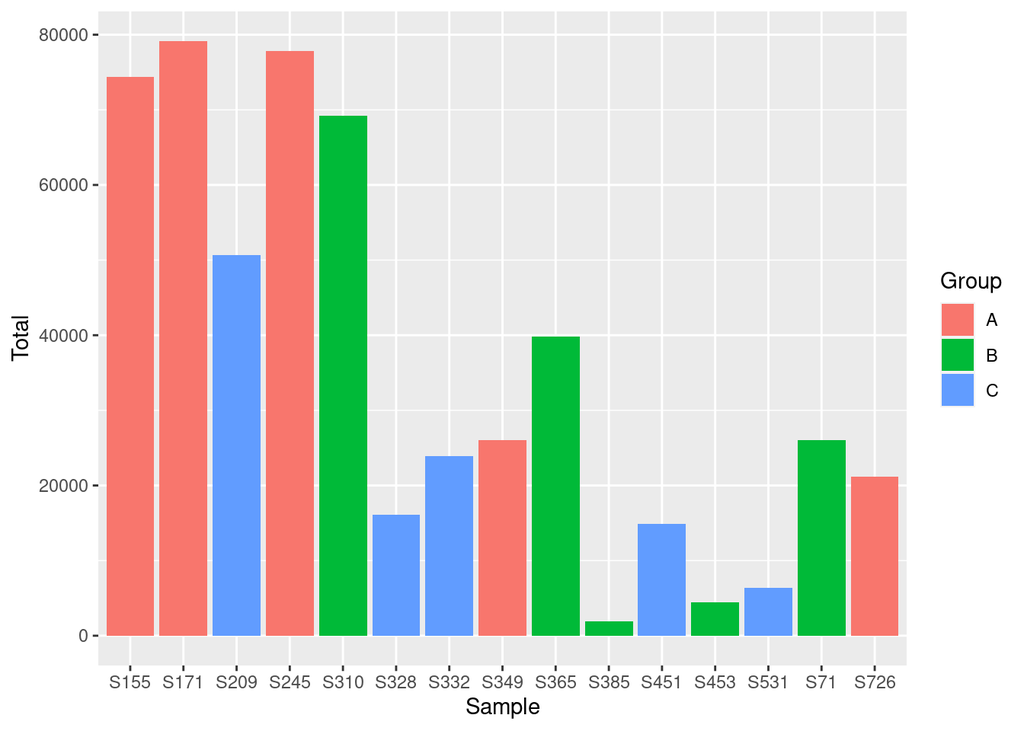

```r
table %>%
  pivot_longer(names_to = "miRNA", values_to = "counts", cols = -Sample) %>%
  group_by(Sample) %>%
  summarise(Total = sum(counts)) %>%
  arrange(Total) %>%
  full_join(meta) %>%
  ggplot(aes(x = Sample, y = Total, fill = Group)) + geom_col()
```

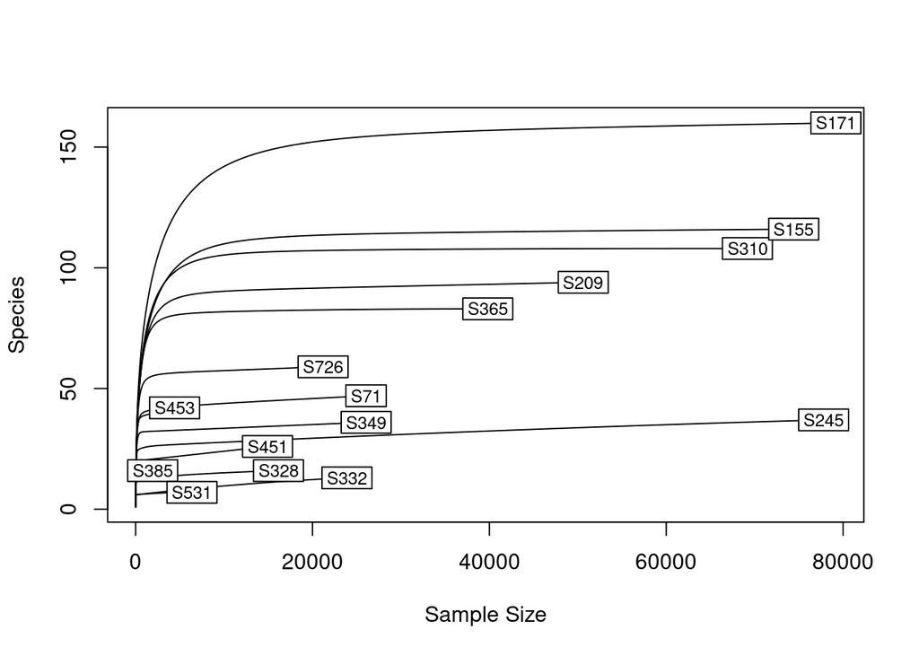

```r
rarecurve(table %>% column_to_rownames("Sample"))
```

Debido al bajo numero de Reads eliminamos las muestras S385, S453, S531 y S332 e igualamos todas las muestras con 14900 Reads (rarefication o subsampling), que como podemos ver en la grafica anterior es suficiente para observar la mayoria de los miRNAs en las muestras.

```r
table_r <- rrarefy(table %>%
                     filter(!Sample %in% c("S385","S453","S531","S332")) %>%
                     column_to_rownames("Sample"), sample = 14900) %>%
  as_tibble(rownames = "Sample")
meta_r <- meta %>%
  filter(!Sample %in% c("S385","S453","S531","332"))
cond_r <- meta_r %>%
  column_to_rownames("Sample")
```

Comprobamos como es la distribucion general de las muestras segun los grupos asociados.

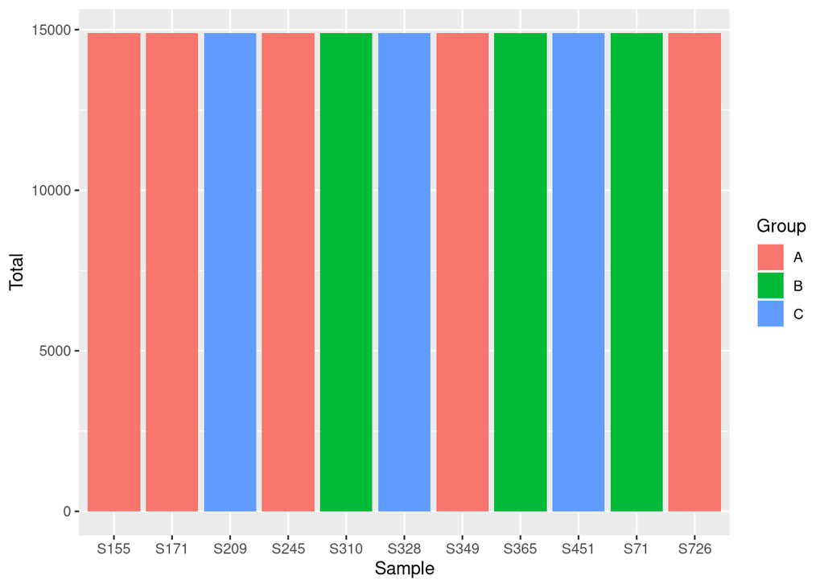

```r
table_r %>%
  pivot_longer(names_to = "miRNA", values_to = "counts", cols = -Sample) %>%
  group_by(Sample) %>%
  summarise(Total = sum(counts)) %>%
  arrange(Total) %>%
  inner_join(meta) %>%
  ggplot(aes(x = Sample, y = Total, fill = Group)) + geom_col()
```

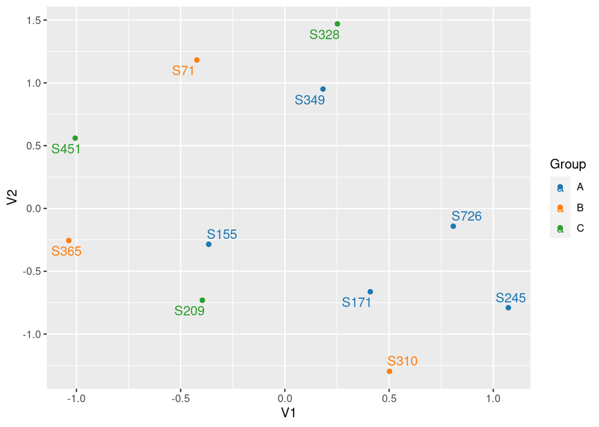

```r
dist <- table_r %>% column_to_rownames("Sample") %>%
 vegdist(method = "bray")

mds <-  dist %>%
 uwot::umap(n_neighbors = 5)


mds %>%
  as_tibble(rownames = "Sample") %>%  inner_join(meta) %>%
  ggplot(aes(x = V1, y = V2, label = Sample, color = Group))  + geom_point() + geom_text_repel() + scale_color_d3()
```

```r
dist <- dist %>% as.matrix() %>% as_tibble(rownames = "Sample") %>% inner_join(meta_r)
dist2 <- dist %>% dplyr::select(-Group) %>% as.data.frame() %>% column_to_rownames("Sample") %>% as.dist()

adonis2(dist2 ~ Group, data = dist)
```

```
## Permutation test for adonis under reduced model
## Terms added sequentially (first to last)
## Permutation: free
## Number of permutations: 999
##
## adonis2(formula = dist2 ~ Group, data = dist)
##          Df SumOfSqs      R2      F Pr(>F)
## Group     2  0.22071 0.21431 1.0911  0.333
## Residual  8  0.80917 0.78569
## Total    10  1.02988 1.00000
```

Vemos que el test estadisto de la PERMANOVA no ha salido significativo. Esto indica que el agrupamiento de las muestras por grupo tiene una gran variabilidad.

Visualizamos en forma de heatmap los miRNAs mas representados en las muestras eliminando aquellos que no estan presentes en almenos 5 muestras

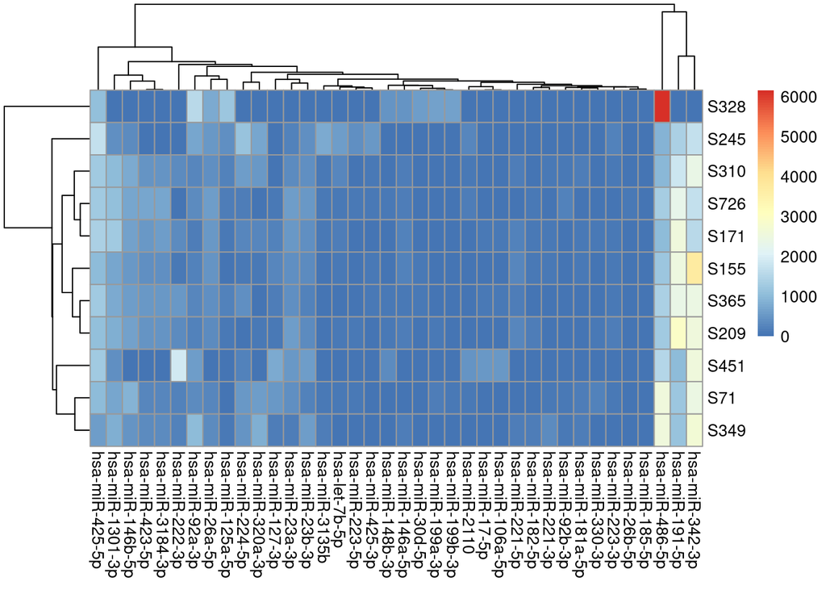

```r
table_r %>%
  pivot_longer(names_to = "miRNA", values_to = "counts", cols = -Sample) %>%
  group_by(miRNA) %>%
  mutate(TotalCounts = sum(counts)) %>%
  mutate(Zeros = sum(counts ==0)) %>%
  filter(Zeros < 5) %>%
  dplyr::select(Sample, miRNA,counts) %>%
  pivot_wider(names_from = miRNA, values_from = counts) %>%
  as.data.frame() %>%
  column_to_rownames("Sample") %>%
  pheatmap::pheatmap()
```

# Analisis diferencial.

Vamos a tratar de identificar aquellos miRNAs que son estadisticamente significativos entre los grupos asociados. Para ello calculamos una GAMLSS (Generalized Aditive Model) asumiento que la distribución de los datos (cuentas de Reads) es composicional (es decir que no estamos observando un cuantificación total sino que son porcentajes de abundancia). Por lo tanto realizaremos un model basado en un distribución de tipo Beta. Los p-values los corregimos por el metodo Benjamini & Hochberg

```r
mod_table2 <- table_r %>%
  pivot_longer(names_to = "miRNA", values_to = "counts",-Sample) %>%
  full_join(meta_r) %>%
  group_by(miRNA) %>%
  mutate(Nzeros = sum(counts ==0)) %>%
  ungroup() %>%
  filter(Nzeros < 4) %>%
  mutate(fraq1 = (counts+1)/14900) %>%
  mutate(fraq2 = counts/14900) %>%
  mutate(counts2 = counts+1) %>%
  nest_by(miRNA) %>%
  mutate(mod_full = list(gamlss(formula = fraq1 ~ Group,
                             data = data,
                             family = "BE",
                             control = gamlss.control(n.cyc = 200, trace = F)))) %>%
  mutate(test = list(emmeans(mod_full, specs = "Group", data = data) %>%
                       pairs() %>%
                       as.data.frame())) %>%
  unnest(test) %>%
  ungroup() %>%
  group_by(contrast) %>%
  mutate(padj = p.adjust(p.value, method = "BH"))
write_tsv(mod_table2 %>% dplyr::select(-data,-mod_full), "TablaComparaciones.tsv")
```

Puedes descargar la tabla de resultados en la siguiente dirección https://github.com/irycisBioinfo/jcmurciano/blob/main/TablaComparaciones.tsv

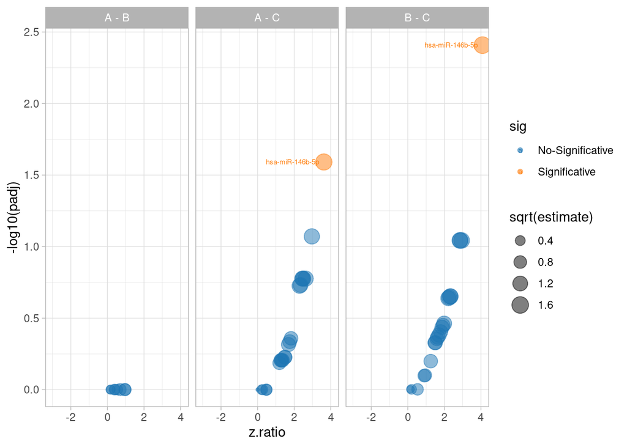

```r
mod_table2 %>%
  mutate(sig = ifelse(padj < 0.05,"Significative","No-Significative")) %>%
  mutate(label = ifelse(sig == "Significative",miRNA,NA)) %>%
  ggplot(aes(x= z.ratio, y = -log10(padj), color = sig, size = sqrt(estimate), label = label)) +
  geom_point(alpha = 0.5) +
  geom_text_repel(size = 2)+
  scale_color_d3() +
  theme_light() +
  facet_grid(~contrast)
```